# 《R + Amos + SPSS》

王超

25-02-2026

# 1 生存分析(Survival Analysis)

- 参考文献
  - 罗欢.养老机构老年人认知衰弱现状及对不良健康结局影响的研究[D].成都中医药大学,2023.DOI:10.26988/d.cnki.gcdzu.2023.000379.

[R ShinyApps - Survival-Analysis](http://127.0.0.1:48577)

- R-Package: survival, DataSet: R lung NCCTG Lung Cancer Data
- Response:
  - T, i.e. , Time-to-Event, Time: Remission time OR **Survival time**.
  - **P(T > t)**
  - Treatment(1) & Placebo(0): Treatment-Effective?
  - Modeling the association between T and X.
    - Median is more interested than Mean.

## 1.1 Survival Function

- The survival function of T is s(t) = P(T > t), t ≥ 0
  - s(0) = 1, s(∞) = 0
  - Decreasing-Function

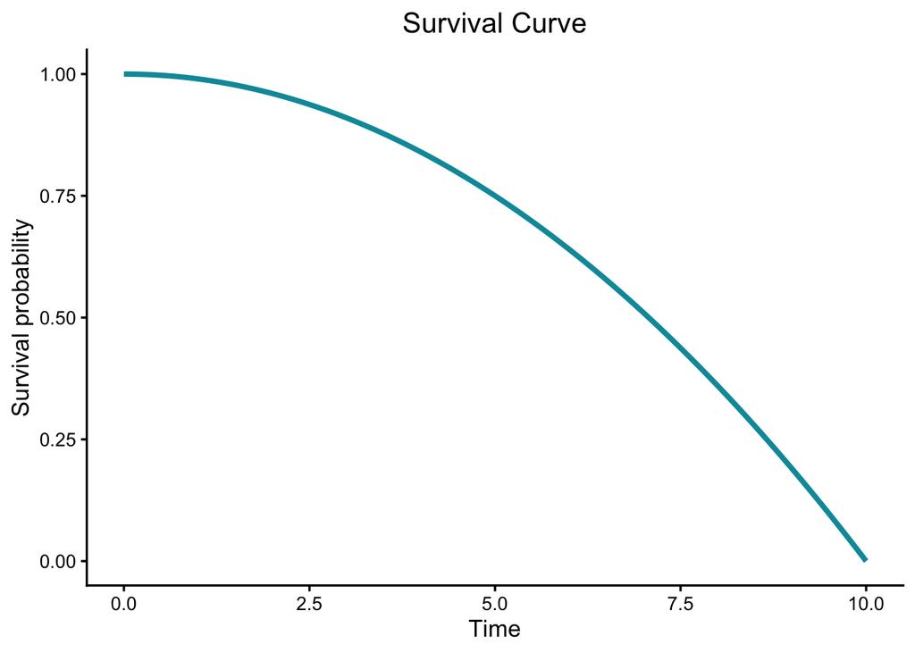

- Treatment(1) & Placebo(0):
  - s(t) = P(T > t | X)
    - s₁(t) = P(T > t | X = 1)
    - s₀(t) = P(T > t | X = 0)
- Comparison of Survival Curves
  - Dominated Survival Curves
  - Crossed Survival Curves
  - Overlapped survival curves
- Dominated Curve

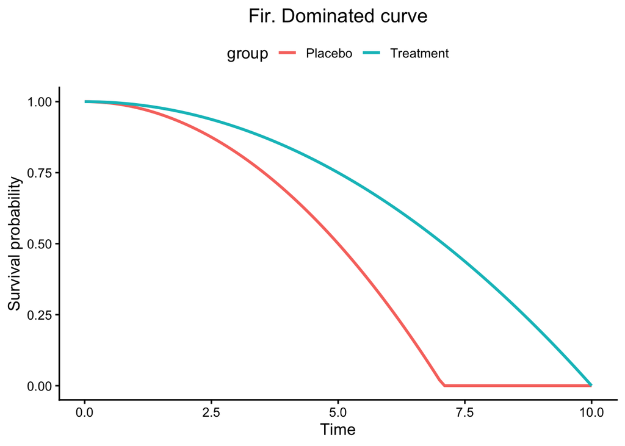

- Crossed Curve

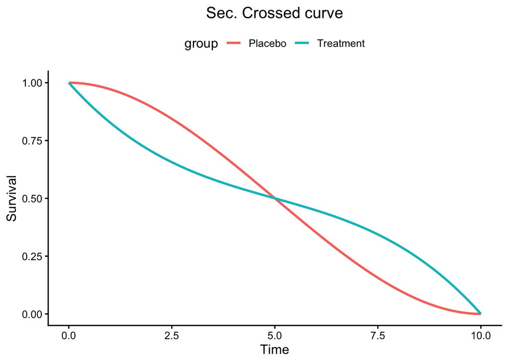

- Overlapped Curve

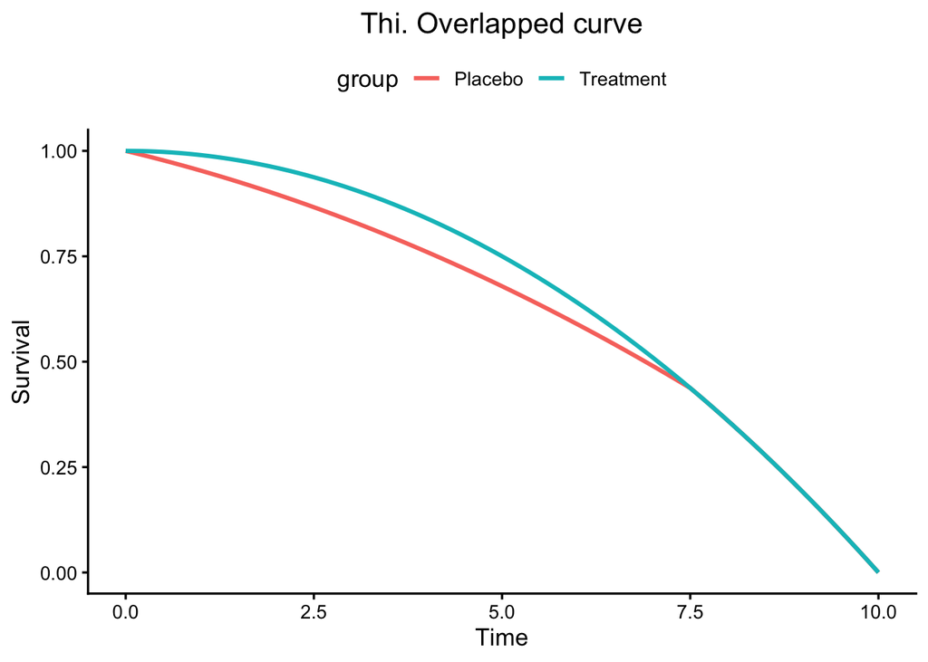

## 1.2 Hazard Function

- h(t) ≈ P(T = t | T ≥ t)
- h(t) ≥ 0
- h(t) ~ s(t)
- s(t) = exp( - H(t)), H(t): Cumulative hazard function.
  - $H(t) = \int_0^t h(u) du$
- h(t) is more interpretable than s(t)

## 1.3 Survival Curve

- Observed Time(Z)
  - Z = Event Time, Censoring Status = 1
  - Z = Censoring Time, Censoring Status = 0
  - Z = Min(Event Time, Censoring Time)
- Censored Data
  - Censored Data: $\big( Z_{i}, \delta_{i}, X_{i} \big) , i = 1, ..., n$
  - $\delta$: Censoring Status
- To plot s(t) based on censored data

## 1.5 Log-Rank Test

- Null Hypothesis: s₀(t) = s₁(t)
  - Estimated Hazard of h₀ ≈ Estimated Hazard of h₁ ≈ Estimated Hazard of (h₀ .and. h₁)
  - $LR\ \sim \ \chi _{df} ( \alpha )$
    - LR = Sum( difference of h )
  - Reject H₀ while $LR\ < \ \chi _{df} ( \alpha )$
- Effect Size
  - ∆RMST(Restricted Mean Survival Time Difference)
  - Hazard Ratio(HR)
  - Log-Rank(LR) Test Effect-Size
- Weighted LR Test
  - Weighted Log-Rank Test

## 1.6 Cox Proportional Hazard(PH) Model

- Cox PH Model for h(t | X)
- HR = exp(coef.)
- Application of the Cox PH Model
- (The study hypothesizes that the independent variable is associated with the risk of the event and **remains an independent predictor** after controlling for potential confounders.)
- Univariate Cox PH Model
  - The univariate Cox proportional hazards model was used to **explore the association** between each variable and the time-to-event outcome.
  - This step focuses on the **direction and magnitude** of the association between individual variables and the event risk.
- Multivariable Cox PH Model
- The multivariable Cox proportional hazards model was applied to evaluate whether the main independent variable is an **independent predictor** of the outcome.
  - Model 1 (**Unadjusted model**):Time ~ Independent
  - Model 2 (**Partially adjusted model**):Time ~ Independent + demographic variables
  - Model 3 (**Fully adjusted model**):Time ~ Independent + demographic variables + potential confounders
  - Hazard ratios (HRs) and 95% confidence intervals (CIs) were reported for all models.
- Interpretation:
  - By comparing the results across models, the stability of the association was assessed.
  - If the independent variable remained statistically significant in the fully adjusted model, it was considered an **independent predictor** of the outcome.
- All Cox models were fitted under the proportional hazards assumption.
- Interpretion of Hazard Ratio(HR)
- **Note**. Cox Proportional Hazards(PH) Assumption